# Лабораторная работа 13

Фильтр пакетов

Баранов Никита Дмитриевич

# Информация

- Баранов Никита Дмитриевич
- студент группы НПИбд-02-24
- Российский университет дружбы народов
- 1132242977@pfur.ru

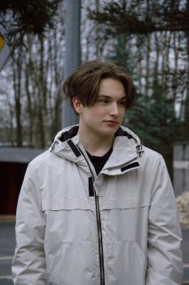

# Цель работы

Получить навыки настройки пакетного фильтра в Linux.

# Задание

1. Используя **firewall-cmd**:  
   – определить текущую зону по умолчанию;  
   – определить доступные зоны;  
   – определить службы в текущей зоне;  
   – добавить `vnc-server`.
2. Используя **firewall-config**:  
   – добавить службы `http`, `ssh`, `ftp`;  
   – добавить порт `2022/udp`.
3. Выполнить задание для самостоятельной работы (раздел 13.5).

# Определение зоны по умолчанию

**Текущая зона по умолчанию:** `public`

# Доступные зоны безопасности

**Доступные зоны:**  
`block dmz drop external home internal nm-shared public trusted work`

# Доступные службы

**Количество доступных служб:** более 200

# Активные службы в зоне

**Активные службы:**  
`cockpit dhcpv6-client ssh`

# Сравнение вывода информации о зоне

**Результат:** команды выводят одинаковую информацию о зоне `public`

# Добавление VNC-server

**Результат:** служба `vnc-server` добавлена (только для текущей сессии)

# Проверка после перезапуска

**Результат:** служба `vnc-server` отсутствует (нужен режим permanent)

# Добавление VNC-server permanent

**Результат:** служба `vnc-server` сохранена в конфигурации

# Перезагрузка конфигурации

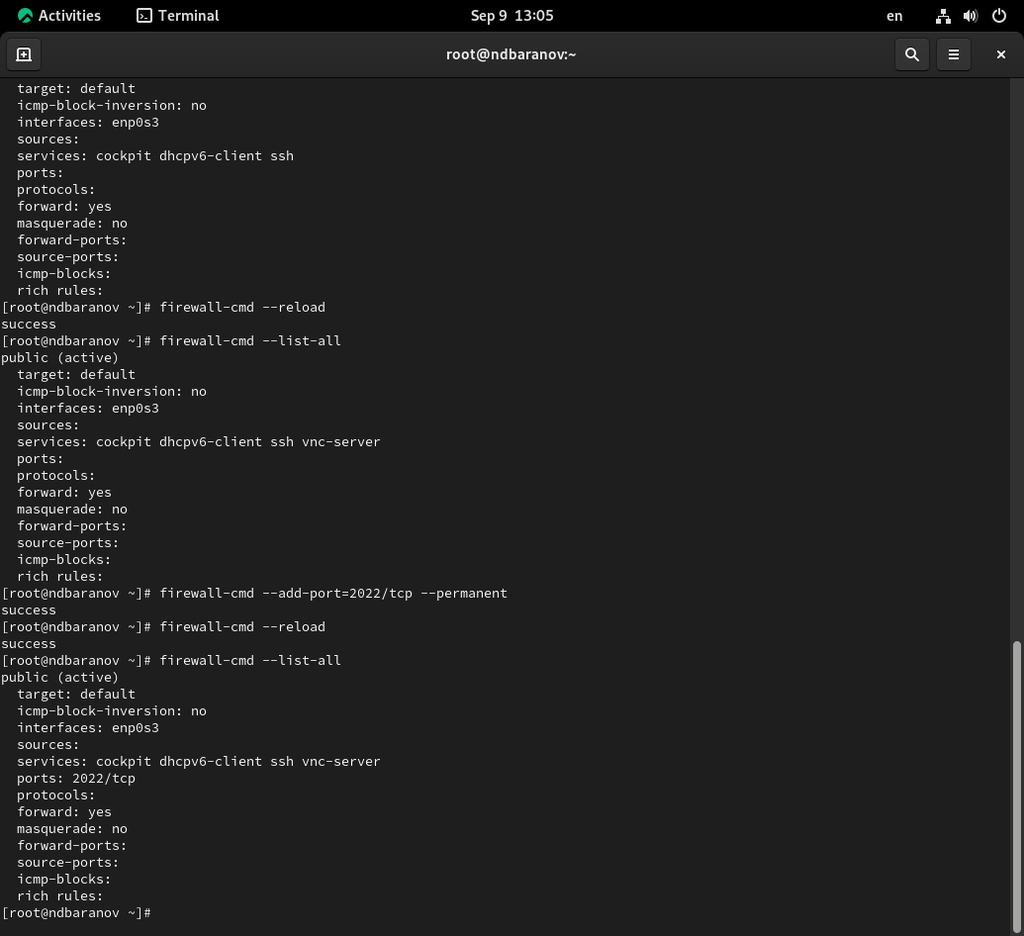

**Результат:** служба `vnc-server` доступна постоянно

# Добавление порта 2022/tcp

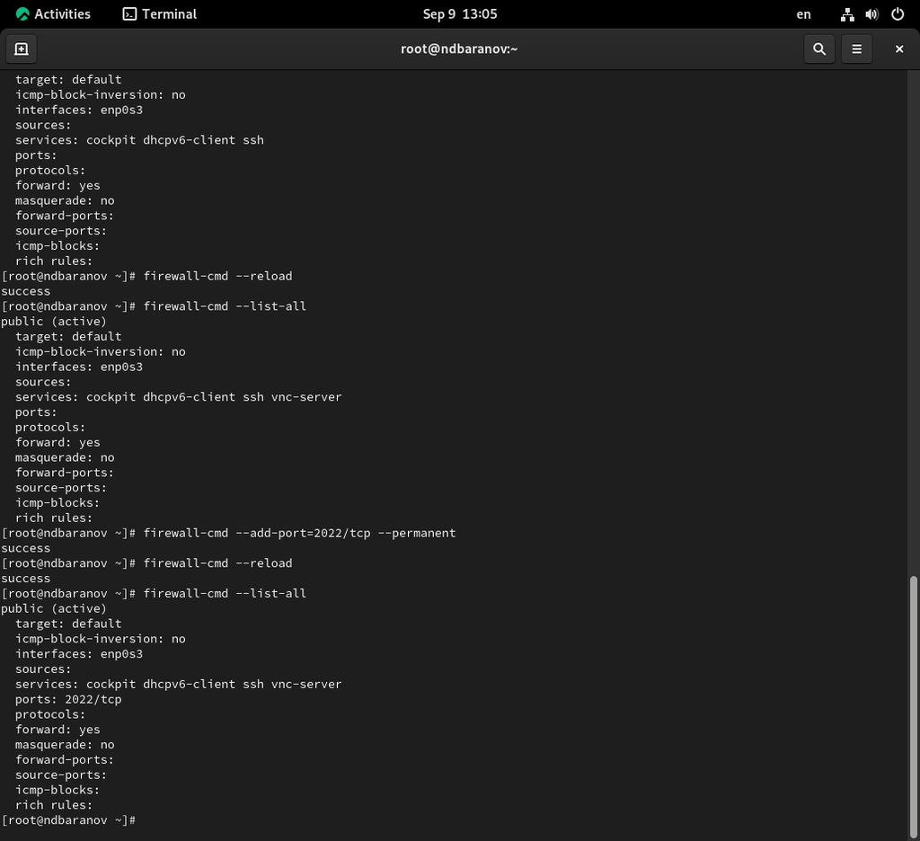

**Результат:** порт `2022/tcp` добавлен в конфигурацию

# Установка firewall-config

**Результат:** графический интерфейс установлен и запущен

# Работа с firewall-config

[figure not shown]

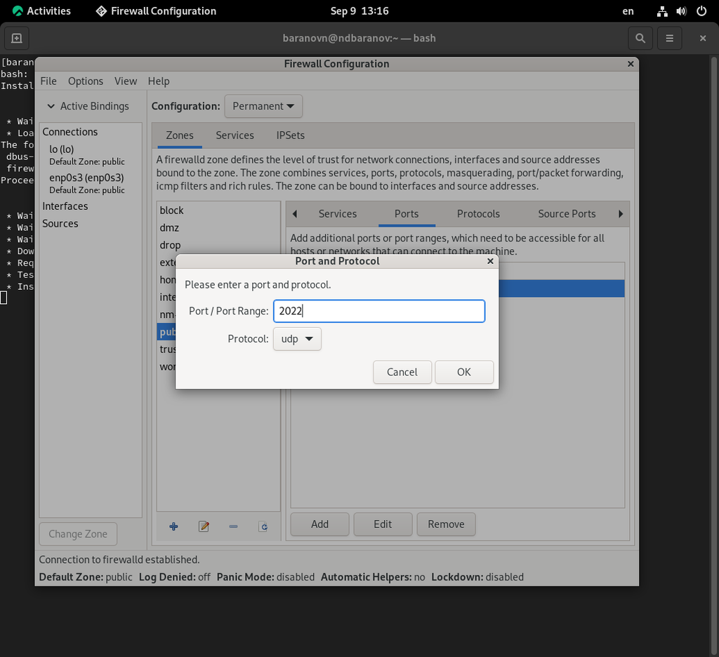

**Выполненные действия:**  
- режим *Permanent*  
- добавлены службы `http`, `https`, `ftp`  
- добавлен порт `2022/udp`

# Проверка после GUI

**Результат:**  
- службы: `cockpit dhcpv6-client ftp http https ssh vnc-server`  
- порты: `2022/tcp 2022/udp`

# Добавление telnet (CLI)

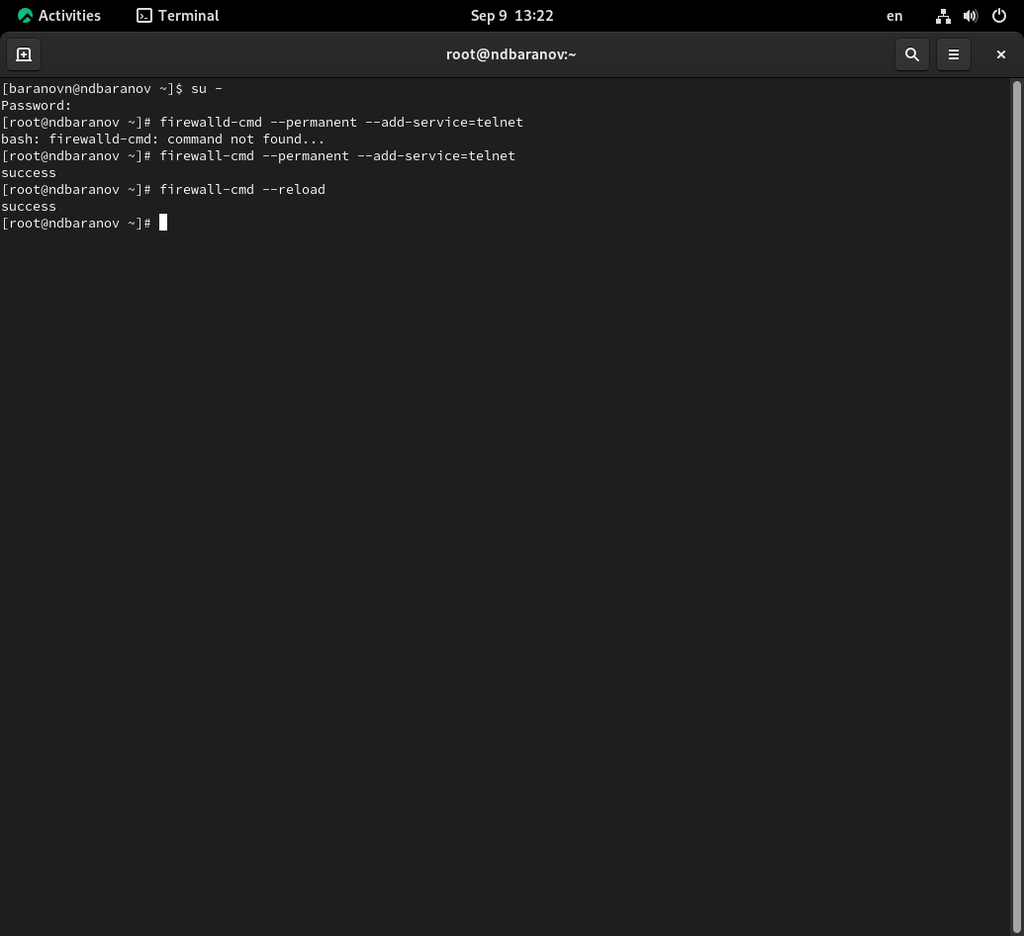

**Команда:**  
`firewall-cmd --permanent --add-service=telnet`

# Добавление почтовых служб (GUI)

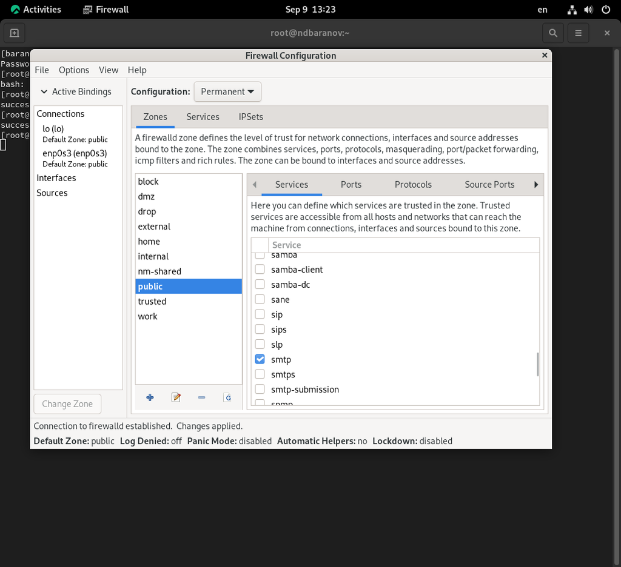

**Добавлено:**  
- `imap`  
- `pop3`  
- `smtp`

# Финальная проверка конфигурации

**Результат:** все изменения применены

# Выводы

- Получены навыки настройки пакетного фильтра в Linux
- Освоена работа с **firewall-cmd** и **firewall-config**
- Настроены зоны, службы и порты
- Изучена разница между временными и постоянными настройками